# FRED Tutorial

6/13/2021

## How to use FRED dataset in R

[FRED(Federal Reserve Economic Data) website](https://fred.stlouisfed.org/) provides various economic data that scholars can utilize in conducting their research. But, it is cumbersome to download data in Excel format and import into R for further analysis. So, this tutorial presents a guide on how to import these data easily. With [**fredr**](https://sboysel.github.io/fredr/index.html) package, we can import data into R directly from FRED website.

This tutorial consists of thee parts as follow.

- Import data into R (ex: unemployment rate in USA)
- Multiple data with similar unit (ex: unemployment rate in Korea and USA)
- Multiple data with different unit (ex: unemployment rate and job openings)

### Load library

Load libraries for [accessing FRED website](https://sboysel.github.io/fredr/index.html), manipulating data, and visualizing output.

```r
library(fredr)
library(tidyverse)
library(ggplot2)
```

To download data from [FRED website](https://fred.stlouisfed.org/), we need to create an account first, then acquire an API key for accessing [FRED API](https://fred.stlouisfed.org/docs/api/fred/). The API key must be set using **fredr_set_key()** function before using **fredr** function.

```
fredr_set_key("YOUR_API_KEY")
```

### Single series

#### Import data into R directly

In this example, we import data of unemployment rate in USA into R. Each data is associated with an unique id and we need to specify it to import. The id of unemployment rate in USA is **UNRATE**. In the following R code, **fredr** function retrieve data specified in **series_id**, convert them into table-like format. The range of data are specified in **observation_start** and **observation_end**.

```r
dataset <- fredr(
  series_id = "UNRATE",
  observation_start = as.Date("1990-01-01"),
  observation_end = as.Date("2000-01-01")
)
```

#### Inspect data

The data consist of 5 columns and 121 observations.

```r
str(dataset)
```

```
## tibble [121 × 5] (S3: tbl_df/tbl/data.frame)
##  $ date          : Date[1:121], format: "1990-01-01" "1990-02-01" ...
##  $ series_id     : chr [1:121] "UNRATE" "UNRATE" "UNRATE" "UNRATE" ...
##  $ value         : num [1:121] 5.4 5.3 5.2 5.4 5.4 5.2 5.5 5.7 5.9 5.9 ...
##  $ realtime_start: Date[1:121], format: "2021-06-14" "2021-06-14" ...
##  $ realtime_end  : Date[1:121], format: "2021-06-14" "2021-06-14" ...
```

The data are sorted by **date**.

```r
dataset %>% head(10)
```

```
## # A tibble: 10 x 5
##    date       series_id value realtime_start realtime_end
##    <date>     <chr>     <dbl> <date>         <date>
##  1 1990-01-01 UNRATE      5.4 2021-06-14     2021-06-14
##  2 1990-02-01 UNRATE      5.3 2021-06-14     2021-06-14
##  3 1990-03-01 UNRATE      5.2 2021-06-14     2021-06-14
##  4 1990-04-01 UNRATE      5.4 2021-06-14     2021-06-14
##  5 1990-05-01 UNRATE      5.4 2021-06-14     2021-06-14
##  6 1990-06-01 UNRATE      5.2 2021-06-14     2021-06-14
##  7 1990-07-01 UNRATE      5.5 2021-06-14     2021-06-14
##  8 1990-08-01 UNRATE      5.7 2021-06-14     2021-06-14
##  9 1990-09-01 UNRATE      5.9 2021-06-14     2021-06-14
## 10 1990-10-01 UNRATE      5.9 2021-06-14     2021-06-14
```

The column **value** indicates unemployment rate. Let’s calculate n, max, min, mean, and median of unemployment rate.

```r
dataset %>% summarize(n=n(), max=max(value), min=min(value), mean = mean(value), median=median(value))
```

```
## # A tibble: 1 x 5
##       n   max   min  mean median
##   <int> <dbl> <dbl> <dbl>  <dbl>
## 1   121   7.8     4  5.75    5.6
```

#### Plot data

Draw line chart of unemployment rate using **ggplot** package.

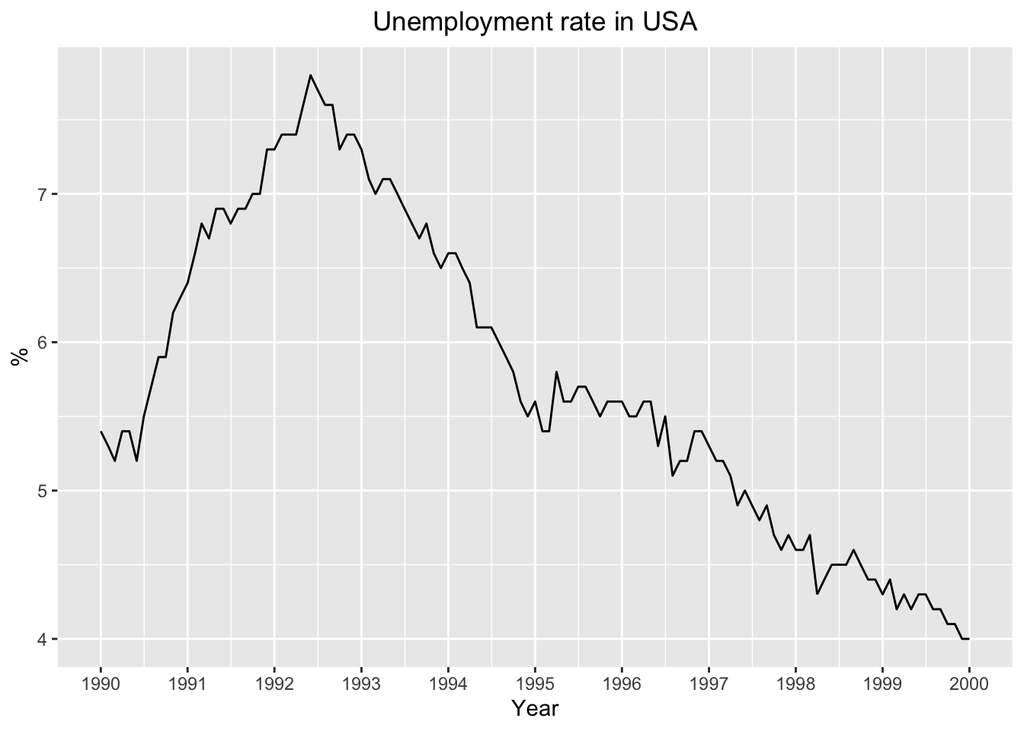

```r
dataset %>%
  ggplot(aes(x=date,y=value)) +
  labs(title="Unemployment rate in USA", x="Year",y="%") +
  theme(plot.title = element_text(hjust = 0.5)) +
  scale_x_date(date_breaks = "year" , date_labels = "%Y") +
  geom_line()
```

### Multiple serieses with identical unit

If we compare two series by plotting them in a single chart, use **map_dfr** to import both series simultaneously. For example, we can compare unemployment rate between Korea and USA.

#### Import data

Acronym referring to unemployment rate in Korea is available at [FRED website](https://fred.stlouisfed.org/series/LRUNTTTTKRM156S).

```r
dataset <- map_dfr(c("UNRATE", "LRUNTTTTKRM156S"), fredr)
```

#### Plot data

When we draw line chart, we need to modify the label of legend to reflect the meaning of each series

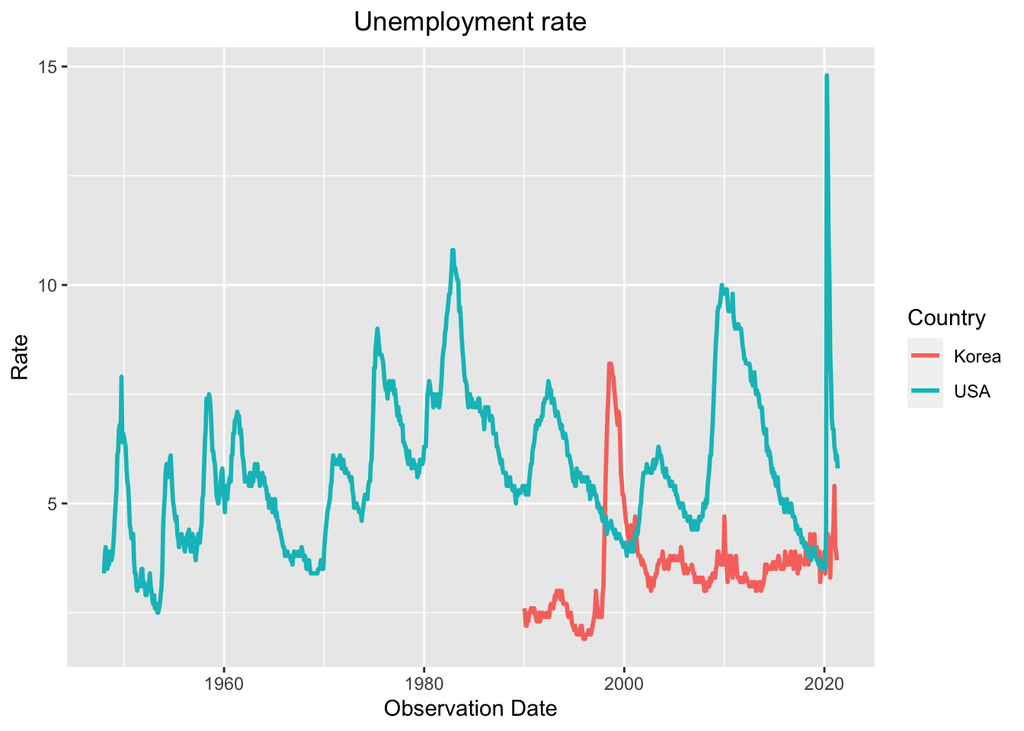

```r
dataset %>%
  ggplot(aes(x = date, y = value, color = series_id)) +
  geom_line(size=1) +
  labs(title="Unemployment rate", x = "Observation Date", y = "Rate", color = "Series") +
  theme(plot.title = element_text(hjust = 0.5)) +
  scale_color_discrete(name="Country",labels = c("Korea", "USA"))
```

### Multiple serieses with different unit

#### Import data

In this case, we import multiple series: unemployment rate and job openings.

```r
dataset <- map_dfr(c("UNRATE", "JTSJOL"), fredr)
dataset
```

```
## # A tibble: 1,126 x 5
##    date       series_id value realtime_start realtime_end
##    <date>     <chr>     <dbl> <date>         <date>
##  1 1948-01-01 UNRATE      3.4 2021-06-14     2021-06-14
##  2 1948-02-01 UNRATE      3.8 2021-06-14     2021-06-14
##  3 1948-03-01 UNRATE      4   2021-06-14     2021-06-14
##  4 1948-04-01 UNRATE      3.9 2021-06-14     2021-06-14
##  5 1948-05-01 UNRATE      3.5 2021-06-14     2021-06-14
##  6 1948-06-01 UNRATE      3.6 2021-06-14     2021-06-14
##  7 1948-07-01 UNRATE      3.6 2021-06-14     2021-06-14
##  8 1948-08-01 UNRATE      3.9 2021-06-14     2021-06-14
##  9 1948-09-01 UNRATE      3.8 2021-06-14     2021-06-14
## 10 1948-10-01 UNRATE      3.7 2021-06-14     2021-06-14
## # … with 1,116 more rows
```

For visualization, we modify table into wider format, where each series become a separate column.

```r
dataset_wider <- dataset %>%
  select(date,series_id,value) %>% pivot_wider(names_from="series_id", values_from="value")
dataset_wider
```

```
## # A tibble: 881 x 3
##    date       UNRATE JTSJOL
##    <date>      <dbl>  <dbl>
##  1 1948-01-01    3.4     NA
##  2 1948-02-01    3.8     NA
##  3 1948-03-01    4       NA
##  4 1948-04-01    3.9     NA
##  5 1948-05-01    3.5     NA
##  6 1948-06-01    3.6     NA
##  7 1948-07-01    3.6     NA
##  8 1948-08-01    3.9     NA
##  9 1948-09-01    3.8     NA
## 10 1948-10-01    3.7     NA
## # … with 871 more rows
```

Now **UNRATE** and **JTSJOL** became separate column. And it can be visualized easily with **ggplot2**.

#### Plot data

Since the unit of **UNRATE** and **JTSJOL** is different, a secondary y axes is added to the right of graph.

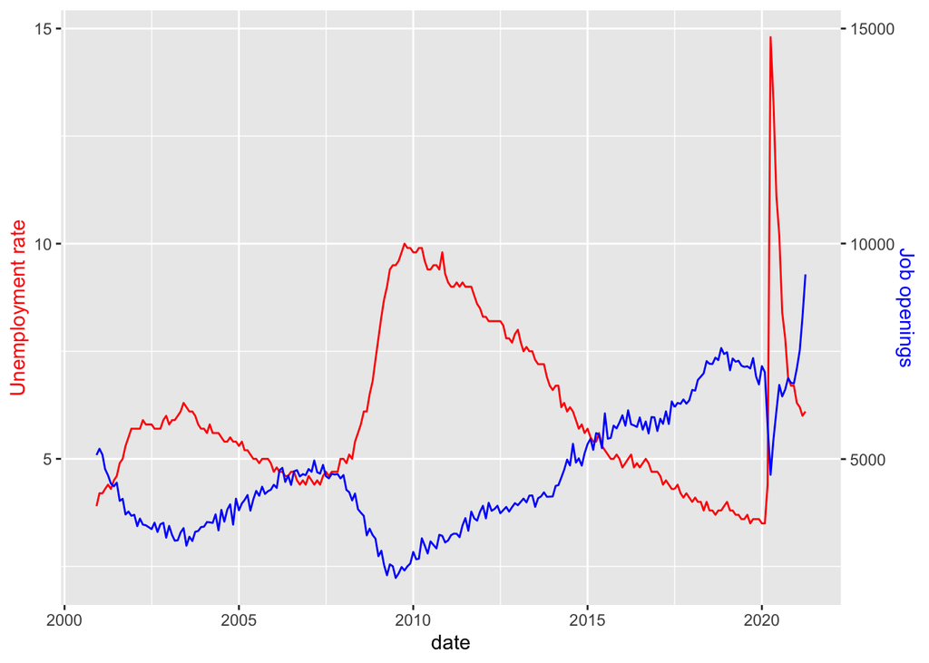

```r
dataset_wider %>%
  drop_na() %>%
  ggplot(aes(x=date)) +
  geom_line( aes(y=UNRATE), color="red") +
  geom_line( aes(y=JTSJOL/1000), color="blue") +
  scale_y_continuous(
    name = "Unemployment rate",
    sec.axis = sec_axis(~.*1000,name="Job openings")) +
  theme(axis.title.y.left = element_text(colour = "red"),
        axis.title.y.right = element_text(colour = "blue"))
```